# Project - NLP ChatBot - Milestone 2 (Model Building)

# Contents:

Problem Statement

Solution Implemented

1. Import & Store the dataset

3. NLP Pre-Processing

4. Machine Learning Classifier

5. Neural Network Classifier

6. LSTM Classifier

7. LSTM Classifier to Predict Accident Level

8. LSTM Classifier to Predict Potential Accident Level

9. Select Best Model

10. Pickle the Best Model

11. Import Chatbot UI Moduel

12. Flash Code

Problem Statement

Solution Implemented Back to Top

Importing the Libraries

```python
import pandas as pd # for Data Analysis
import numpy as np # for Numerical calculations
import matplotlib.pyplot as plt # for Graphical representation
%matplotlib inline
import seaborn as sns
sns.set (color_codes=True) # setting the colors
sns.set(style="whitegrid")
from scipy.stats import norm

import tensorflow as tf # for Tensorflow network
from tensorflow.keras.models import Sequential # to add sequential layers
from tensorflow.keras.layers import Flatten # to add the flatten layer
from tensorflow.keras.layers import Dense, Embedding,LSTM,Bidirectional,GlobalMaxPooling1D,Dropout,Conv1D # to add multiple layers, dropouts etc
from tensorflow.keras import regularizers, optimizers # to import regularizer and optimizers
from tensorflow.keras.preprocessing import sequence
from tensorflow.keras.preprocessing.text import Tokenizer
from sklearn.preprocessing import LabelEncoder

from nltk.corpus import stopwords # to exclude stopwords
import re # for regular expression
from nltk.stem.wordnet import WordNetLemmatizer # Word lemmatizer

from sklearn.preprocessing import StandardScaler
from sklearn.model_selection import train_test_split # to split the data into train & Test
from sklearn import metrics # to use metrics function of sklearn
import random # for consistent random results
random.seed(0) # to ensure the redundant results
import pickle

import warnings # for Warning
warnings.filterwarnings('ignore') # to avoid showing warnings
print("\033[1mLibraries imported \033[0m \n")  # Print message
```

```
Libraries imported
```

1. Import & Store the Dataset Back to Top

```python
# safety_df=pd.read_excel('updated_data.xlsx')
try:
    safety_df=pd.read_excel('updated_data.xlsx')
except FileNotFoundError:
    print('Please Provide the correct File "updated_data.xlsx" ')
```

```python
safety_df.head()
```

|  | Unnamed: 0 | Data | Countries | Local | Industry Sector | Accident Level | Potential Accident Level | Genre | Employee or Third Party | Critical Risk | Description |
| --- | --- | --- | --- | --- | --- | --- | --- | --- | --- | --- | --- |
| 0 | 0 | 2016-01-01 | Country_01 | Local_01 | Mining | I | IV | Male | Third Party | Mechanical Failure | While removing the drill rod of the Jumbo 08 f... |
| 1 | 1 | 2016-01-02 | Country_02 | Local_02 | Mining | I | IV | Male | Employee | Chemical substances | During the activation of a sodium sulphide pum... |
| 2 | 2 | 2016-01-06 | Country_01 | Local_03 | Mining | I | III | Male | Third Party (Remote) | hit by something | In the sub-station MILPO located at level +170... |
| 3 | 3 | 2016-01-08 | Country_01 | Local_04 | Mining | I | I | Male | Third Party | Mechanical Failure | approximately in the the personnel begins the ... |
| 4 | 4 | 2016-01-10 | Country_01 | Local_04 | Mining | IV | IV | Male | Third Party | Mechanical Failure | Approximately at 11:45 a.m. in circumstances t... |

2.1 Attribute : Country

```python
safety_df['Countries']=safety_df['Countries'].map({'Country_01' : 0, 'Country_02' : 1,'Country_03' : 2})
```

2.2 Attribute : Local

```python
safety_df['Local']=safety_df['Local'].map({'Local_01' : 0, 'Local_02' : 1,'Local_03' : 2,'Local_04' : 3,'Local_05' : 4,'Local_06' : 5,
                                        'Local_07' : 6, 'Local_08' : 7,'Local_09' : 8,'Local_10' : 9,'Local_11' : 10,'Local_12' : 11})
```

2.3 Attribute : Industry Sector

```python
safety_df['Industry Sector']=safety_df['Industry Sector'].map({'Mining' : 0, 'Metals' : 1,'Others' : 2})
```

2.4 Attribute : Accident Level

```python
safety_df['Accident Level']=safety_df['Accident Level'].map({'I' : 0, 'II' : 1,'III' : 2,'IV' : 3,'V' : 4})
```

2.5 Attribute : Potiential Accident Level

```python
safety_df['Potential Accident Level']=safety_df['Potential Accident Level'].map({'I' : 0, 'II' : 1,'III' : 2,'IV' : 3,'V' : 4,'VI' : 5})
```

2.6 Attribute : Gender

```python
safety_df['Genre']=safety_df['Genre'].map({'Male' : 0, 'Female' : 1})
```

2.7 Attribute : Employment Type (Employee or Third Party)

```python
safety_df['Employee or Third Party']=safety_df['Employee or Third Party'].map({'Third Party' : 0, 'Employee' : 1,'Third Party (Remote)' : 2})
```

2.8 Attribute : Unnamed & Data - Dropped

```python
safety_df=safety_df.drop(['Unnamed: 0','Data'], axis=1)
```

```python
# #created Common Code for Data cleansing
# def data_cleansing():
#     safety_df['Countries']=safety_df['Countries'].map({'Country_01' : 0, 'Country_02' : 1,'Country_03' : 2})

#     safety_df['Local']=safety_df['Local'].map({'Local_01' : 0, 'Local_02' : 1,'Local_03' : 2,'Local_04' : 3,'Local_05' : 4,'Local_06' : 5,
#                                         'Local_07' : 6, 'Local_08' : 7,'Local_09' : 8,'Local_10' : 9,'Local_11' : 10,'Local_12' : 11})
#     return "ok-data_cleansing"
```

3. NLP Pre-Processing Back to Top

```python
# clean_df = pd.DataFrame()
def NLPpreprocessing():
    """This function is used the pre-Process the text data.
It will create a new DF with cleaned data.
This function used in the automation of task using UI"""

    global tokenizer
    global word_index
    global embedding_size
    global maxlen
    global vocab_size

    global clean_df



    wl=WordNetLemmatizer()

    def clean_up(x):
        check=re.compile('[^A-Za-z0-9\s]')
        text=check.sub('',x)
        text=text.lower()
        text = re.sub(r"[,.\"\'!@#$%^&*(){}?/;`~:<>+=-]", "", text)
        text=text.split()
        text=[wl.lemmatize(word) for word in text if not word in stopwords.words('english')]
        text=' '.join(text)
        return text

    def CleanTokenize(df):
        corpus = list()
        lines = df.values.tolist()

        for line in lines:
            line = clean_up(line)
            corpus.append(line)
        return corpus

    corpus=CleanTokenize(safety_df['Description'])
    safety_df['Clean_description']=pd.DataFrame(corpus)

    max_features = 1000 # Number of words to take from tokenizer(most frequent words)
    maxlen = 100 # Maximum length of each sentence to be limited to
    embedding_size = 200 # size of embedding vector

    # Tokenizer
    tokenizer = Tokenizer(num_words=max_features, split=' ')
    tokenizer.fit_on_texts(safety_df['Clean_description'].values)
    X_desc = tokenizer.texts_to_sequences(safety_df['Clean_description'].values)

    # Word Indexing
    word_index=tokenizer.word_index
    vocab_size = len(tokenizer.word_index) + 1

    #Padding
    X_desc=sequence.pad_sequences(X_desc,maxlen=maxlen)


    # Convert into a DataFrame
    X_desc=pd.DataFrame(X_desc)
    #Merge with Main DF
    clean_df=pd.concat([X_desc,safety_df],axis=1)

    #remove description and clean_description
    clean_df=clean_df.drop(['Description','Clean_description'],axis=1)

    NLPpreprocessing_status='Data Preprocessing Completed' # used in HTML Code for output of fuction
    return (clean_df,NLPpreprocessing_status)
```

```python
def export_to_excel():
    """This function is export the cleaned DF in excel.
This function used in the automation of task using UI."""

    clean_df,NLPpreprocessing_status=NLPpreprocessing()
    if clean_df.empty:
        return  ("Data Preprocessing not compelted completed!")
    else:
        clean_df.to_excel("clean_df.xlsx")
        return("Clean Data Saved in Project folder with file name clean_df.xlsx ")
```

```python
export_to_excel()
```

```
'Clean Data Saved in Project folder with file name clean_df.xlsx '
```

```python
# print(export_to_excel.__doc__)
```

4. Machine Learning Classifier Back to Top

```python
def MLClassifier():
    """This function get the cleaned DF from  NLPpreprocessing.
Create multilpe ML model.
This function used in the automation of task using UI. """

    # Import Cleaned Data
#     ML_DF=NLPpreprocessing()
    ML_DF,NLPpreprocessing_status=NLPpreprocessing()

    #Remove low count classes and others
    ML_DF = ML_DF.groupby('Critical Risk').filter(lambda x: len(x) > 15)
    ML_DF = ML_DF[ML_DF['Critical Risk'] != 'others']


    # Lable encode the Class
    lb1 = LabelEncoder()
    ML_DF['Critical Risk'] = lb1.fit_transform(ML_DF[['Critical Risk']])

    # Define X & Y
    ML_X=ML_DF.drop(['Critical Risk','Accident Level','Potential Accident Level'], axis=1)
    ML_y=ML_DF['Critical Risk']


    #Split the Data
    X_train,X_test,y_train,y_test=train_test_split(ML_X,ML_y,test_size=0.20,random_state=1)

    scaler = StandardScaler()
    X_train = scaler.fit_transform(X_train)
    X_test = scaler.transform(X_test)



    from sklearn.pipeline import make_pipeline

    from sklearn.linear_model import LogisticRegression # for Logistic regression model
    from sklearn.naive_bayes import GaussianNB # for Gaussina Naive Bayes model
    from sklearn.neighbors import KNeighborsClassifier # for KNN model
    from sklearn.svm import SVC # for SVM Model
    from sklearn.tree import DecisionTreeClassifier # for Decision Tree Classifier
    from sklearn.ensemble import BaggingClassifier # for Bagging Classifier
    from sklearn.ensemble import AdaBoostClassifier # for Ada Boosting Classifier
    from sklearn.ensemble import GradientBoostingClassifier # for Graident Boosting Classifier
    from sklearn.ensemble import RandomForestClassifier # For Random Forest Classifier

    pipe=[]

    pipe.append(make_pipeline(StandardScaler(),LogisticRegression()))
    pipe.append(make_pipeline(StandardScaler(),GaussianNB()))
    pipe.append(make_pipeline(StandardScaler(),KNeighborsClassifier()))
    pipe.append(make_pipeline(StandardScaler(),SVC()))
    pipe.append(make_pipeline(StandardScaler(),DecisionTreeClassifier()))
    pipe.append(make_pipeline(StandardScaler(),BaggingClassifier()))
    pipe.append(make_pipeline(StandardScaler(),AdaBoostClassifier()))
    pipe.append(make_pipeline(StandardScaler(),GradientBoostingClassifier()))
    pipe.append(make_pipeline(StandardScaler(),RandomForestClassifier()))

    cvtest_results={}
    for l,i in enumerate(pipe):

        name,pipeline= i
        pipeline.fit(X_train,y_train)
        Accuracy_train=pipeline.score(X_train,y_train)
        Accuracy_test=pipeline.score(X_test,y_test)
        a=str(pipeline)
        a=a[:-2]
        cvtest_results[name]=a,Accuracy_train,Accuracy_test

    MLClassifier_status='Machine Learning Classifiers Created'
    return (cvtest_results.values(),MLClassifier_status)
```

```python
cvtest_results,MLClassifier_status=MLClassifier()
MLClassifier_status
```

```
'Machine Learning Classifiers Created'
```

```python
print (MLClassifier.__doc__)
```

```
This function get the cleaned DF from  NLPpreprocessing.
Create multilpe ML model.
This function used in the automation of task using UI.
```

5. Neural Network Classifier Back to Top

```python
def NN_Classifier():
    """This function get the cleaned DF from  NLPpreprocessing.
Create Neural Network model.
This function used in the automation of task using UI. """

#     NN_DF=NLPpreprocessing()
    NN_DF,NLPpreprocessing_status=NLPpreprocessing()
    lb2 = LabelEncoder()

    #Remove low count classes and others
    NN_DF = NN_DF.groupby('Critical Risk').filter(lambda x: len(x) > 15)
    NN_DF = NN_DF[NN_DF['Critical Risk'] != 'others']

    NN_DF['Critical Risk'] = lb2.fit_transform(NN_DF[['Critical Risk']])

    # Define X & Y
    NN_X=NN_DF.drop(['Critical Risk','Accident Level','Potential Accident Level'], axis=1)
    NN_y=NN_DF['Critical Risk']

    #Split the Data
    X_train,X_test,y_train,y_test=train_test_split(NN_X,NN_y,test_size=0.20,random_state=1)

    from tensorflow.keras.utils import to_categorical
    y_train = to_categorical(y_train)
    y_test = to_categorical(y_test)


    embeddings_index = dict()
    f = open('glove.6B.200d.txt',encoding="utf-8")
    for line in f:
        values = line.split()
        word = values[0]
        coefs = np.asarray(values[1:], dtype='float32')
        embeddings_index[word] = coefs
    f.close()
    #print('Loaded %s word vectors.' % len(embeddings_index))

    embedding_matrix = np.zeros((len(word_index) + 1, 200))
    for word, i in tokenizer.word_index.items():
        embedding_vector = embeddings_index.get(word)
        if embedding_vector is not None:
            embedding_matrix[i] = embedding_vector

#     print(vocab_size,embedding_size,maxlen)
    model1 = Sequential()
    model1.add(Embedding(vocab_size, embedding_size,weights=[embedding_matrix], input_length=maxlen,trainable=True))
    model1.add(Conv1D(64, 3, activation='relu'))
    model1.add(Dropout(0.7))
    model1.add(GlobalMaxPooling1D())
    model1.add(Dense(64, activation='relu'))
    model1.add(Dropout(0.5))
    model1.add(Dense(16, activation='relu'))
    model1.add(Dense(len(NN_y.unique()), activation='softmax'))
    model1.compile(loss='categorical_crossentropy',optimizer='adam',metrics=['accuracy'])
    history = model1.fit(X_train, y_train, batch_size=16, epochs=200, validation_data=(X_test, y_test), verbose=0)

    score,acc_NN_train = model1.evaluate(X_train, y_train, verbose = 0, batch_size = 32)
    score,acc_NN_test = model1.evaluate(X_test, y_test, verbose = 0, batch_size = 32)
    model_name='Neural Network Classifier'
    #print("Model Accuracy is : %.4f" % (acc_NN))
    #Print accuracy and losss  plot
    plt.plot(history.history['accuracy'])
    plt.plot(history.history['val_accuracy'])
    plt.title('model accuracy')
    plt.ylabel('accuracy')
    plt.xlabel('epoch')
    plt.legend(['train','test'], loc='upper left')
    plt.show()
    plt.plot(history.history['loss'])
    plt.plot(history.history['val_loss'])

    plt.title('model loss')
    plt.ylabel('loss')
    plt.xlabel('epoch')
    plt.legend(['train','test'], loc='upper left')
    plt.show()

    nnClassifier_status='Neural Netwrok Classifier Created'
    return model_name,acc_NN_train,acc_NN_test,model1,lb2,nnClassifier_status
```

[output not shown]

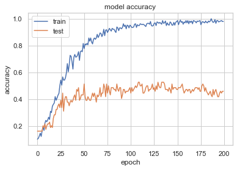

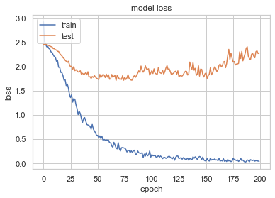

```python
nn_model_name,acc_NN_train,acc_NN_test,model1,lb2,nnClassifier_status=NN_Classifier()
```

```python
# print(NN_Classifier.__doc__)
# print(nn_model_name,acc_NN_train,acc_NN_test,model1,lb2,nnClassifier_status)
nnClassifier_status
```

```
'Neural Netwrok Classifier Created'
```

6. LSTM Classifier Back to Top

```python
def LSTM_Classifier():
    """This function get the cleaned DF from  NLPpreprocessing.
Create LSTM  model.
This function used in the automation of task using UI. """

#     LSTM_DF=NLPpreprocessing()
    LSTM_DF,NLPpreprocessing_status=NLPpreprocessing()
    lb3 = LabelEncoder()

    #Remove low count classes and others
    LSTM_DF = LSTM_DF.groupby('Critical Risk').filter(lambda x: len(x) > 15)
    LSTM_DF = LSTM_DF[LSTM_DF['Critical Risk'] != 'others']

    LSTM_DF['Critical Risk'] = lb3.fit_transform(LSTM_DF[['Critical Risk']])

    # Define X & Y
    LSTM_X=LSTM_DF.drop(['Critical Risk','Accident Level','Potential Accident Level'], axis=1)
    LSTM_y=LSTM_DF['Critical Risk']

    #Split the Data
    X_train,X_test,y_train,y_test=train_test_split(LSTM_X,LSTM_y,test_size=0.20,random_state=1)

    from imblearn.over_sampling import SMOTE
    X_train, y_train = SMOTE(k_neighbors=5,random_state=1).fit_resample(X_train, y_train)


    from tensorflow.keras.utils import to_categorical
    y_train = to_categorical(y_train)
    y_test = to_categorical(y_test)


    embeddings_index = dict()
    f = open('glove.6B.200d.txt',encoding="utf-8")
    for line in f:
        values = line.split()
        word = values[0]
        coefs = np.asarray(values[1:], dtype='float32')
        embeddings_index[word] = coefs
    f.close()
    print('Loaded %s word vectors.' % len(embeddings_index))

    embedding_matrix = np.zeros((len(word_index) + 1, 200))
    for word, i in tokenizer.word_index.items():
        embedding_vector = embeddings_index.get(word)
        if embedding_vector is not None:
            embedding_matrix[i] = embedding_vector


    model2 = Sequential()
    model2.add(Embedding(vocab_size, embedding_size,weights=[embedding_matrix], input_length=maxlen,trainable=False))
    model2.add((LSTM(56,dropout=0.6, recurrent_dropout=0.3)))
    model2.add(Dense(10, activation='relu'))
    model2.add(Dropout(0.5))
    model2.add(Dense(len(LSTM_y.unique()), activation='softmax'))
    model2.compile(loss='categorical_crossentropy',optimizer='adam',metrics=['accuracy'])
    history = model2.fit(X_train, y_train, batch_size=32, epochs=200, validation_data=(X_test, y_test), verbose=0)

    score,acc_LSTM_train = model2.evaluate(X_train, y_train, verbose = 0, batch_size = 32)
    score,acc_LSTM_test = model2.evaluate(X_test, y_test, verbose = 0, batch_size = 32)
    model_name='LSTM_Classifier'
    #print("Model Accuracy is : %.4f" % (acc_LSTM))

    #Print accuracy and losss  plot
    plt.plot(history.history['accuracy'])
    plt.plot(history.history['val_accuracy'])
    plt.title('model accuracy')
    plt.ylabel('accuracy')
    plt.xlabel('epoch')
    plt.legend(['train','test'], loc='upper left')
    plt.show()
    plt.plot(history.history['loss'])
    plt.plot(history.history['val_loss'])

    plt.title('model loss')
    plt.ylabel('loss')
    plt.xlabel('epoch')
    plt.legend(['train','test'], loc='upper left')
    plt.show()

    lstmClassifier_status='LSTM Netwrok Classifier Created'
    return model_name,acc_LSTM_train,acc_LSTM_test,model2,lb3,lstmClassifier_status
```

[output not shown]

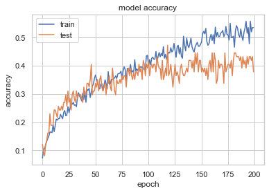

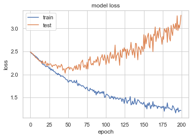

```
'LSTM Netwrok Classifier Created'
```

```python
lstm_model_name,acc_LSTM_train,acc_LSTM_test,model2,lb3,lstmClassifier_status=LSTM_Classifier()
lstmClassifier_status
```

```python
acc_LSTM_train,acc_LSTM_test
```

```
(0.8860543966293335, 0.37837839126586914)
```

7. Accident Level Classifier Back to Top

```python
def Accident_Level_Classifier():
    """This function get the cleaned DF from  NLPpreprocessing.
Create Accident Level Classifier  model."""

#     Accident_DF=NLPpreprocessing()
    Accident_DF,NLPpreprocessing_status=NLPpreprocessing()

    lb4 = LabelEncoder()
    Accident_DF['Critical Risk'] = lb4.fit_transform(Accident_DF[['Critical Risk']])


    # Define X & Y
    Accident_X=Accident_DF.drop(['Accident Level'], axis=1)
    Accident_y=Accident_DF['Accident Level']

    #Split the Data
    X_train,X_test,y_train,y_test=train_test_split(Accident_X,Accident_y,test_size=0.20,random_state=1)

    from tensorflow.keras.utils import to_categorical
    y_train = to_categorical(y_train)
    y_test = to_categorical(y_test)

    model3=Sequential()
    model3.add(Embedding(vocab_size,embedding_size,input_length=maxlen))
    model3.add((LSTM(128,dropout=0.35, recurrent_dropout=0.2)))
    model3.add(Dense(56,activation='relu'))
    model3.add(Dense(28,activation='relu'))
    model3.add(Dense(len(Accident_y.unique()),activation='softmax'))
    model3.compile(loss='categorical_crossentropy',optimizer='adam',metrics=['accuracy'])
    #print(model3.summary())
    history = model3.fit(X_train, y_train, batch_size=128, epochs=10, validation_data=(X_test, y_test), verbose=0)

    score,acc_accident_level_train = model3.evaluate(X_train, y_train, verbose = 0, batch_size = 32)
    score,acc_accident_level_test = model3.evaluate(X_test, y_test, verbose = 0, batch_size = 32)
    model_name = 'Accident_Level'

    #Print accuracy and losss  plot
    plt.plot(history.history['accuracy'])
    plt.plot(history.history['val_accuracy'])
    plt.title('model accuracy')
    plt.ylabel('accuracy')
    plt.xlabel('epoch')
    plt.legend(['train','test'], loc='upper left')
    plt.show()
    plt.plot(history.history['loss'])
    plt.plot(history.history['val_loss'])

    plt.title('model loss')
    plt.ylabel('loss')
    plt.xlabel('epoch')
    plt.legend(['train','test'], loc='upper left')
    plt.show()

    return model_name,acc_accident_level_train,acc_accident_level_test,model3
```

[output not shown]

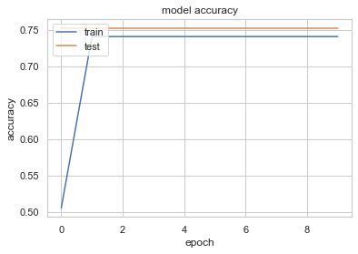

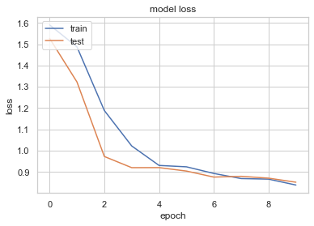

```python
model_name,acc_accident_level_train,acc_accident_level_test,model3=Accident_Level_Classifier()
```

8. Potential Accident Level Classifier Back to Top

```python
def Potential_Accident_Level_Classifier():
    """This function get the cleaned DF from  NLPpreprocessing.
Create Accident Level Classifier  model."""
#     Potential_Accident_DF=NLPpreprocessing()
    Potential_Accident_DF,NLPpreprocessing_status,=NLPpreprocessing()


    lb5 = LabelEncoder()
    Potential_Accident_DF['Critical Risk'] = lb5.fit_transform(Potential_Accident_DF[['Critical Risk']])

    # Define X & Y

    Potential_Accident_X=Potential_Accident_DF.drop(['Potential Accident Level'], axis=1)
    Potential_Accident_y=Potential_Accident_DF['Potential Accident Level']

    #Split the Data
    X_train,X_test,y_train,y_test=train_test_split(Potential_Accident_X,Potential_Accident_y,test_size=0.20,random_state=1)

    from tensorflow.keras.utils import to_categorical
    y_train = to_categorical(y_train, num_classes=len(Potential_Accident_y.unique()))
    y_test = to_categorical(y_test, num_classes=len(Potential_Accident_y.unique()))

    model4=Sequential()
    model4.add(Embedding(vocab_size,embedding_size,input_length=maxlen))
    model4.add((LSTM(128,dropout=0.35, recurrent_dropout=0.2)))
    model4.add(Dense(56,activation='relu'))
    model4.add(Dense(28,activation='relu'))
    model4.add(Dense(len(Potential_Accident_y.unique()),activation='softmax'))
    model4.compile(loss='categorical_crossentropy',optimizer='adam',metrics=['accuracy'])
    history = model4.fit(X_train, y_train, batch_size=28, epochs=10, validation_data=(X_test, y_test), verbose=0)

    score,acc_pot_accident_level_train = model4.evaluate(X_train, y_train, verbose = 0, batch_size = 32)
    score,acc_pot_accident_level_test = model4.evaluate(X_test, y_test, verbose = 0, batch_size = 32)
    model_name='Potential Accident Level'
    #print("Model Accuracy is : %.4f" % (acc_pot_accident_level))
    #Print accuracy and losss  plot
    plt.plot(history.history['accuracy'])
    plt.plot(history.history['val_accuracy'])
    plt.title('model accuracy')
    plt.ylabel('accuracy')
    plt.xlabel('epoch')
    plt.legend(['train','test'], loc='upper left')
    plt.show()
    plt.plot(history.history['loss'])
    plt.plot(history.history['val_loss'])

    plt.title('model loss')
    plt.ylabel('loss')
    plt.xlabel('epoch')
    plt.legend(['train','test'], loc='upper left')
    plt.show()

    return model_name,acc_pot_accident_level_train,acc_pot_accident_level_test,model4
```

[output not shown]

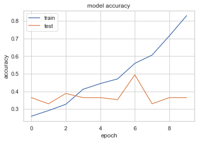

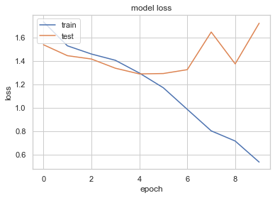

```python
model_name,acc_pot_accident_level_train,acc_pot_accident_level_test,model4=Potential_Accident_Level_Classifier()
```

9. Select Best Model Back to Top

```python
# Create DF with ML Model result
cvtest_results=pd.DataFrame(cvtest_results,columns=['Model_Name','Train_Accuracy','Test_Accuracy'])
cvtest_results
```

|  | Model_Name | Train_Accuracy | Test_Accuracy |
| --- | --- | --- | --- |
| 0 | LogisticRegression | 0.709898 | 0.229730 |
| 1 | GaussianNB | 0.201365 | 0.121622 |
| 2 | KNeighborsClassifier | 0.430034 | 0.175676 |
| 3 | SVC | 0.484642 | 0.243243 |
| 4 | DecisionTreeClassifier | 1.000000 | 0.175676 |
| 5 | BaggingClassifier | 0.989761 | 0.243243 |
| 6 | AdaBoostClassifier | 0.204778 | 0.121622 |
| 7 | GradientBoostingClassifier | 1.000000 | 0.229730 |
| 8 | RandomForestClassifier | 1.000000 | 0.229730 |

```python
# Create DF and append NN & LSTM  Model results

results=cvtest_results.append({'Model_Name' : nn_model_name,'Train_Accuracy': acc_NN_train,'Test_Accuracy' : acc_NN_test},ignore_index=True)


results=results.append({'Model_Name' : lstm_model_name,'Train_Accuracy': acc_LSTM_train,'Test_Accuracy' : acc_LSTM_test},ignore_index=True)
```

```python
results
```

|  | Model_Name | Train_Accuracy | Test_Accuracy |
| --- | --- | --- | --- |
| 0 | LogisticRegression | 0.709898 | 0.229730 |
| 1 | GaussianNB | 0.201365 | 0.121622 |
| 2 | KNeighborsClassifier | 0.430034 | 0.175676 |
| 3 | SVC | 0.484642 | 0.243243 |
| 4 | DecisionTreeClassifier | 1.000000 | 0.175676 |
| 5 | BaggingClassifier | 0.989761 | 0.243243 |
| 6 | AdaBoostClassifier | 0.204778 | 0.121622 |
| 7 | GradientBoostingClassifier | 1.000000 | 0.229730 |
| 8 | RandomForestClassifier | 1.000000 | 0.229730 |
| 9 | Neural Network Classifier | 1.000000 | 0.459459 |
| 10 | LSTM_Classifier | 0.886054 | 0.378378 |

```python
def select_best_classifiers():
    val=results['Test_Accuracy'].max()
    index_val=results.index[results['Test_Accuracy'] == val]
    i=index_val[0]

    best_classifiers_status="Best Classifier is: "+ str([results.iloc[i,0]][0]) + " and Train Accuracy is: " + str(round(results.iloc[i,1],4)) + " Test Accuracy is: " + str(round(results.iloc[i,2],4))
    return best_classifiers_status
```

```python
select_best_classifiers()
```

```
'Best Classifier is: Neural Network Classifier and Train Accuracy is: 1.0 Test Accuracy is: 0.4595'
```

10. Pickle the Best Model Back to Top

```python
# This function is used to create Pickle file.

def create_pickelfile ():

    pickle.dump(lb2, open("lb.pickle.dat", "wb"))
    model1.save("predict_model.pickle.h5")
    model3.save("accident_predict_model.pickle.h5")
    model4.save("potential_accident_predict_model.pickle.h5")

    pickel_status="Pickle file created for the model "

    return pickel_status
```

```python
create_pickelfile()
```

```
'Pickle file created for the model '
```

11. Import Charbot UI Module Back to Top

```python
import Chatbot_Interface as ci
# This file is used to import the chatbot UI module
```

```python
#ci.chatbot()
```

12. Flask Code Back to Top

```python
# ci.call_func()
```

```python
from flask import Flask, render_template
import datetime
from flask import request
import pandas as pd
import test as eda
# import ChatBot_Prediction_Modelv1 as cpm

app = Flask(__name__)


# Start -Load Default page ------------


@app.route('/')
def loadhomepage():
    now = datetime.datetime.now()
    timeString = now.strftime("%Y-%m-%d %H:%M")
    templateData = {
        'title': 'AIML Chatbot',
        'time': timeString
    }
    return render_template('homepage.html', **templateData)


# End -Load Default page ------------

# Start -Load another page- Import data used for automate the Functionality  ------------

@app.route("/uploadfile", methods=['GET', 'POST'])
def importfile():
    return render_template('importdata.html')


# End -Load another page- Import data used for automate the Functionality  ------------


# Start -Upload CSV file and save in  project directory   ------------

@app.route("/upload", methods=['GET', 'POST'])
def upload_file():
    print("hi")

    if request.method == 'POST':

        f = request.files['files']
        f.save(f.filename)
        print("File Name---",f)
        txt=f.filename[-4:]

        if txt.upper()!='XLSX': # Validate excel format only
            return ("Please provide xlsx document")

        df = pd.read_excel(f.filename)
        #  print the shape of DF
        data_count = df.shape
        row = data_count[0]
        col = data_count[1]
        return_txt = "File uploaded successfully with data -" + "Column :" + str(col) + " and " + "Row:" + str(row)
        # return return_txt

    return return_txt

# End -Upload CSV/excel file and save in  project directory   ------------



# Start -import Data preprocessing function  ------------

@app.route("/data_preprocessing", methods=['GET', 'POST'])
def get_data_preprocessing():
    print("post method-1")
    if request.method == 'POST':
#          print("pr1-1")
         clean_df,data_preprocessing_status=NLPpreprocessing()


    return data_preprocessing_status

# End -import Data preprocessing function    ------------


# Start -Export Data  function  ------------

@app.route("/data_export", methods=['GET', 'POST'])
def export_data():
    if request.method == 'POST':
        print("pr1-2")
        export_data_csv = export_to_excel()
        print("pr1-2", export_data_csv)

    return export_data_csv

# End -Export Data  function    ------------


# Start -ml_classifiers function  ------------

@app.route("/ml_classifiers", methods=['GET', 'POST'])
def ml_classifiers():
    if request.method == 'POST':
#         ml_classifiers_status = mlclassifier_op()

        cvtest_results,MLClassifier_status=MLClassifier()

    return MLClassifier_status

# End -ml_classifiers   function    ------------


# Start -nn_classifiers   function  ------------

@app.route("/nn_classifiers", methods=['GET', 'POST'])
def nn_classifiers():
    if request.method == 'POST':
#         nn_classifiers_status = eda.nl_classifiers_model()
        model_name,acc_NN_train,acc_NN_test,model1,lb2,nnClassifier_status=NN_Classifier()

    return nnClassifier_status

# End -nn_classifiers  function    ------------


# Start -lstm_classifiers   function  ------------

@app.route("/lstm_classifiers", methods=['GET', 'POST'])
def lstm_classifiers():
    if request.method == 'POST':
#         lstm_classifiers_status = eda.lstm_classifiers_model()
        model_name,acc_LSTM_train,acc_LSTM_test,model2,lb3,lstmClassifier_status=LSTM_Classifier()

    return lstmClassifier_status

# End -lstm_classifiers  function    ------------


# Start -best_classifiers   function  ------------

@app.route("/best_classifiers", methods=['GET', 'POST'])
def best_classifiers():
    if request.method == 'POST':
        print('best_classifiers')
        best_classifiers_status = select_best_classifiers()
        print('best_classifierspost',best_classifiers_status)

    return best_classifiers_status

# End -best_classifiers  function    ------------


# Start -Pickle best _classifiers   function  ------------

@app.route("/pickle_model", methods=['GET', 'POST'])
def pickle_model():
    if request.method == 'POST':
        print('best_classifiers1')
        pickle_classifiers_status = create_pickelfile()


    return pickle_classifiers_status

# End -Pickle best _classifiers  function    ------------

# --Call chatbot------start-------------

@app.route("/chatbot", methods=['GET', 'POST'])
def call_func():
    print("post method-1")
    ci.chatbot()
    return render_template('homepage.html')

# --Call chatbot------end-------------

if __name__ == '__main__':
    app.run(host='localhost', port=8092, )
```

```
 * Serving Flask app "__main__" (lazy loading)
 * Environment: production
   WARNING: This is a development server. Do not use it in a production deployment.
   Use a production WSGI server instead.
 * Debug mode: off
```

```
 * Running on http://localhost:8092/ (Press CTRL+C to quit)
127.0.0.1 - - [27/Apr/2021 19:30:09] "GET / HTTP/1.1" 200 -
```

[output not shown]